# Open data survey

# Question 33

> Please select all that apply:
> - Fosters collaboration
> - Validates findings
> - Complements data
> - Avoids duplication
> - No benefit
> - Other (please specify)

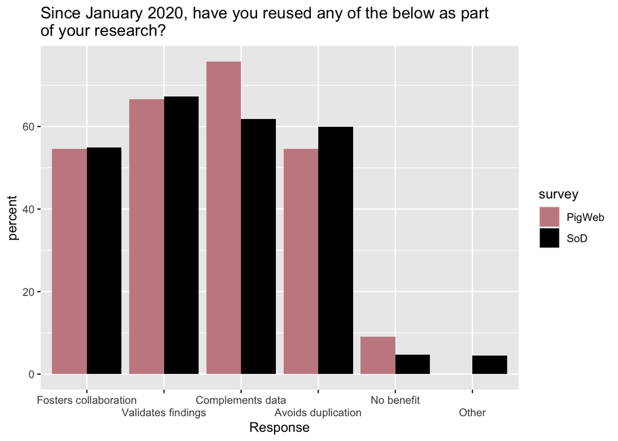

Figure 33.1

```r
# Answered by Lina

# This is a multiple-choice question stored as one indicator column per response option.

#Checking that index corresponds to right question
# colnames(sod21)[106:112]
# colnames(pigw21)[118:124]

# Giving the answer options to Question 33 - the ticks on the x axis when plotting
Q33.1_levels = c("Fosters collaboration", "Validates findings", "Complements data", "Avoids duplication", "No benefit", "Other")

# Create data frames of answers from both surveys - by extracting the multiple columns of the respective data frame that contains the answers

pigw21Q33.1 <- as.data.frame(dplyr::select(pigw21, 118:123))
sod21Q33.1 = as.data.frame(dplyr::select(sod21, 106:109,111,110))

# Checking if there are any individuals with no answer to the question - if either is TRUE add a "no answer" level
# all(rowSums(is.na(pigw21Q33.1)) == ncol(pigw21Q33.1))
# all(rowSums(sod21Q33.1 == 0) == ncol(sod21Q33.1))

# Storing the question - later used to give our plot a title
Q33.1 <- 'Since January 2020, have you reused any of the below as part of your research?'

# Creating a data frame containing percentages for each option for plotting multiple-choice questions: arguments in this order:
# 1. sod_data (represent columns with each available answers)
# 2. pigweb_data (represent columns with each available answers)
# 3. levels is a vector of the options
Q33.1_data <- format_question_multiple_choice(sod21Q33.1, pigw21Q33.1, Q33.1_levels)

# Plotting a bar chart of percentages for a multiple choice questions: arguments in this order:
# 1. Data frame produced by format_question_multiple_choice
# 2. Vector of the answer options
# 3. Character string of plot title - Q32 question
# 4. Character string for the x-axis label (not a separate vector, write text below)

plot_multiple_choice(Q33.1_data, Q33.1_levels, Q33.1, "Response")
```

# Question 34

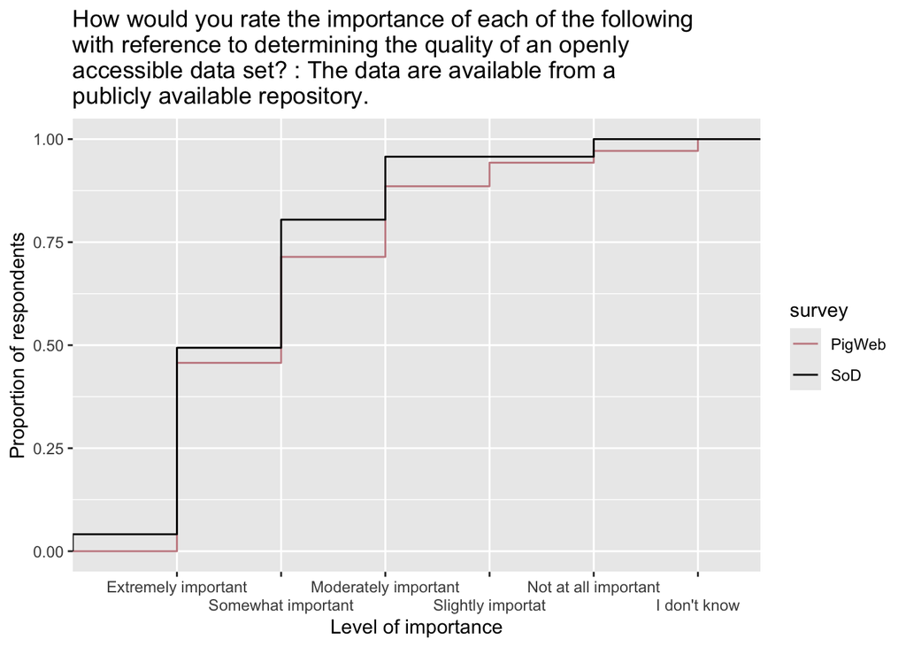

Figure Q34

```r
pigw21Q34 = as.data.frame(dplyr::select(pigw21, 126))
pigw21Pile = cbind(pigw21Pile, pigw21Q34)

#Setting column names and storing the question
colnames(pigw21Q34) = c('Q34')
Q34 = 'How would you rate the importance of each of the following with reference to determining the quality of an openly accessible data set? : The data are available from a publicly available repository.'

#Setting the answer options to Question Q19.
Q34_levels = c("Extremely important", "Somewhat important", "Moderately important", "Slightly importat", "Not at all important", "I don't know")

sod21Q34 = as.data.frame(dplyr::select(sod21,129))
sod21Pile = cbind(sod21Pile, sod21Q34)
colnames(sod21Q34) = c('Q34')


Q34_data = format_question_likert(sod21Q34$Q34,
                                 pigw21Q34$Q34,
                                 Q34_levels)

#Likert plot
plot_likert(Q34_data,
            Q34_levels,
            Q34,
            "Level of importance")
```

```r
#This section test for if there is statistically significant difference in the respondent groups
#with the null hypothesis that the two populations are the same.

ks.test(Q34_data$response[Q34_data$survey == "SoD"],
        Q34_data$response[Q34_data$survey == "PigWeb"],
        ifresult = FALSE) #Kolmogorov-Smirnov test for Q34
```

[output not shown]

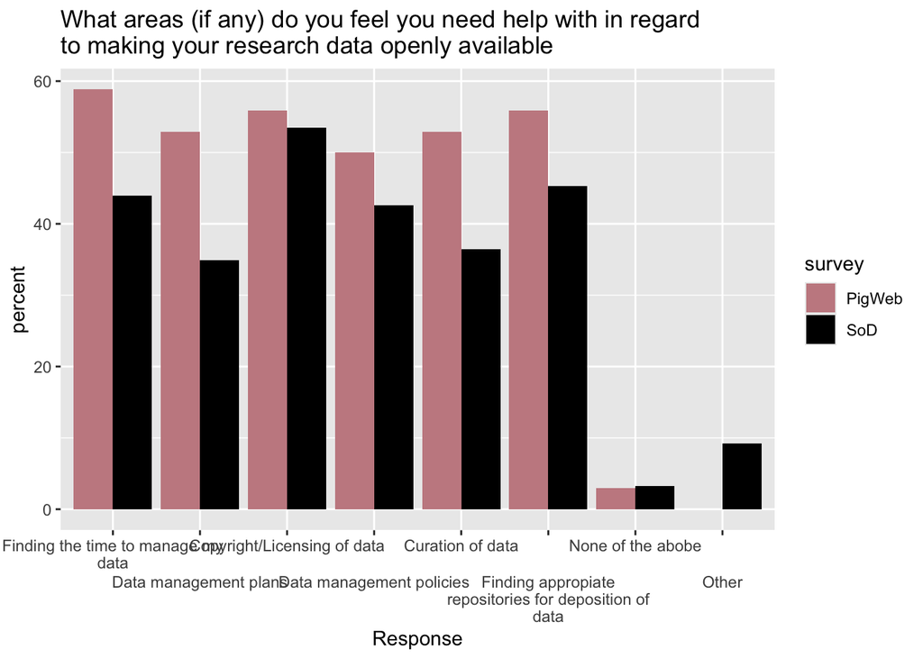

Figure QP3

```r
#Paulina Q3
#What areas (if any) do you feel you need help with in regard to making your research data openly available.
#This code chunk uses the multiple choice functions.
QP3_levels = c("Finding the time to manage my data",
              "Data management plans",
              "Copyright/Licensing of data",
              "Data management policies",
              "Curation of data",
              "Finding appropiate repositories for deposition of data",
              "None of the abobe",
              "Other")
n_columns = length(QP3_levels)

sod21QP3 = as.data.frame(dplyr::select(sod21, (87:sum(87,n_columns,-1))))
sod21Pile = cbind(sod21Pile, sod21QP3)

pigw21QP3 = as.data.frame(dplyr::select(pigw21, (67:sum(67,n_columns-1))))
pigw21Pile = cbind(pigw21Pile, pigw21QP3)

QP3 = 'What areas (if any) do you feel you need help with in regard to making your research data openly available'


QP3_data = format_question_multiple_choice(sod21QP3,
                                          pigw21QP3,
                                          QP3_levels)

plot_multiple_choice(QP3_data,
                     QP3_levels,
                     QP3,
                     "Response")
```

# Question 37

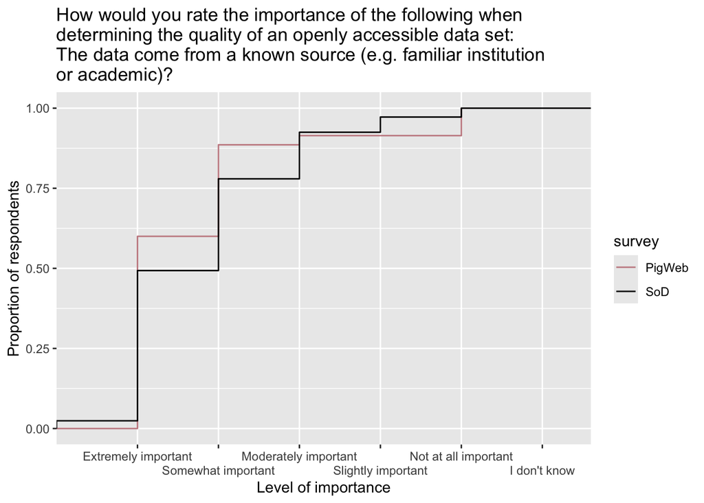

Figure 37

```r
# Answered by Marios
# sod21
# pigw21
# colnames(sod21)[130]
# colnames(pigw21)[127]
#Keep only the Q37
sod21Q37 = as.data.frame(dplyr::select(sod21, 130))
sod21Pile = cbind(sod21Pile, sod21Q37)

pigw21Q37 = as.data.frame(dplyr::select(pigw21, 127))
pigw21Pile = cbind(pigw21Pile, pigw21Q37)

#Setting columnnames and question 37
colnames(sod21Q37) = c('Q37')
colnames(pigw21Q37) = c('Q37')

Q37 = 'How would you rate the importance of the following when determining the quality of an openly accessible data set: The data come from a known source (e.g. familiar institution or academic)?'

#Setting the answer options to Q37.
Q37_levels = c("Extremely important", "Somewhat important",
               "Moderately important", "Slightly important",
               "Not at all important", "I don't know")

Q37_data = format_question_likert(sod21Q37$Q37, #Making the answers to Q37 in the two questionnaires comparable, merging them to one data frame
                                  pigw21Q37$Q37,
                                  Q37_levels)

plot_likert(Q37_data,  #Plotting the Level of importance
            Q37_levels,
            Q37,
            "Level of importance")
```

# Question 38

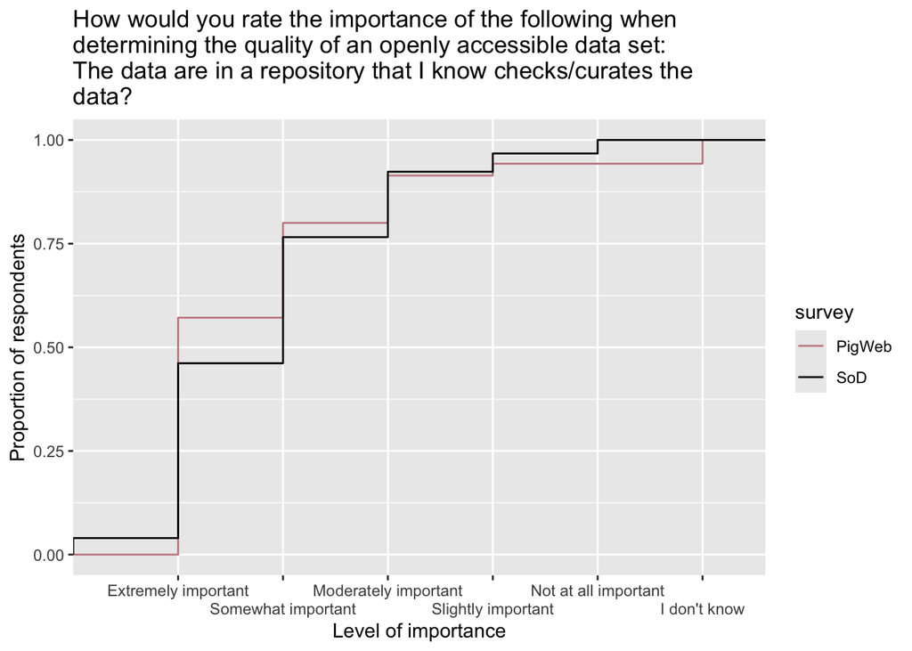

Figure 38

```r
# Answered by Marios
# sod21
# pigw21
# colnames(sod21)[131]
# colnames(pigw21)[128]
#Keep only the Q38
sod21Q38 = as.data.frame(dplyr::select(sod21, 131))
sod21Pile = cbind(sod21Pile, sod21Q38)

pigw21Q38 = as.data.frame(dplyr::select(pigw21, 128))
pigw21Pile = cbind(pigw21Pile, pigw21Q38)

#Setting columnnames and question 38
colnames(sod21Q38) = c('Q38')
colnames(pigw21Q38) = c('Q38')

Q38 = 'How would you rate the importance of the following when determining the quality of an openly accessible data set: The data are in a repository that I know checks/curates the data?'

# Setting the answer options to Q38
Q38_levels = c("Extremely important", "Somewhat important",
               "Moderately important", "Slightly important",
               "Not at all important", "I don't know")


# The PigWeb scale is correctly formatted for this question, thus no need to reverse the question.

Q38_data = format_question_likert(
  sod21Q38$Q38,
  pigw21Q38$Q38,
  Q38_levels)


plot_likert(
  Q38_data,
  Q38_levels,
  Q38,
  "Level of importance")
```

# Question 45

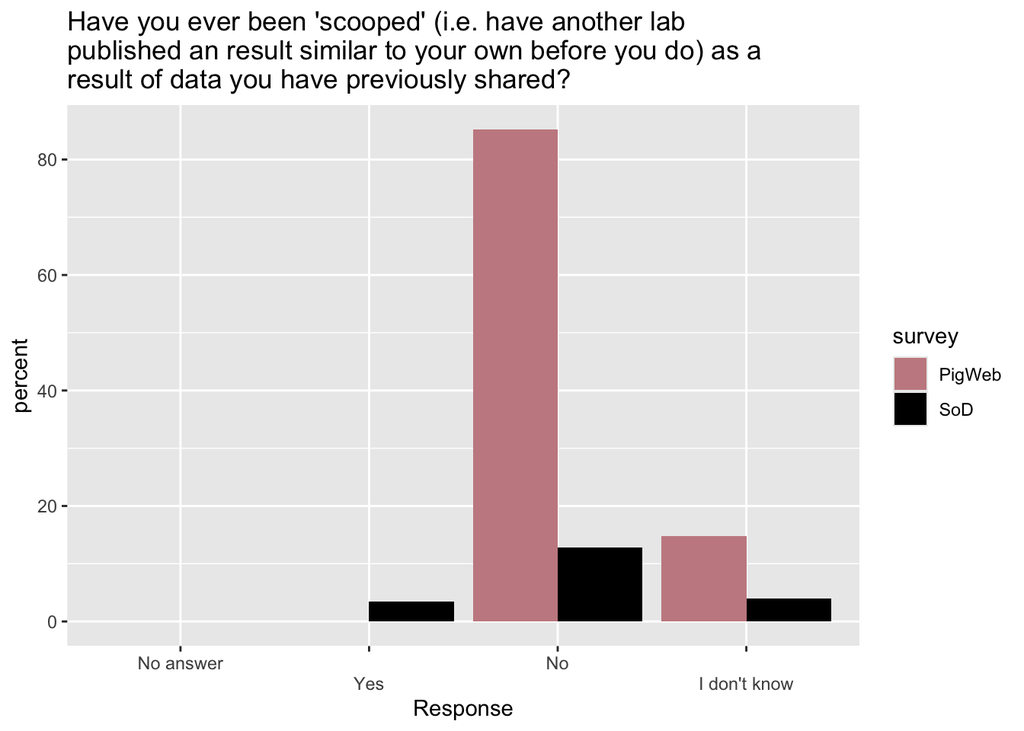

Figure 45

```r
#Creating data sets for Q45/Isolating the responses from Q45
pigw21Q45 = as.data.frame(dplyr::select(pigw21, 114))
pigw21Pile = cbind(pigw21Pile, pigw21Q45)

sod21Q45 = as.data.frame(dplyr::select(sod21, 86))
sod21Pile = cbind(sod21Pile, sod21Q45)

#Saving the Question text and changing the column name with the responses in the two data frames to Q45
Q45 = "Have you ever been 'scooped' (i.e. have another lab published an result similar to your own before you do) as a result of data you have previously shared?"
colnames(pigw21Q45) = c('Q45')
colnames(sod21Q45) = c('Q45')

Q45_levels = c("Yes", "No", "I don't know") #The different levels/categories of the questions

Q45_data = format_question_single_choice(sod21Q45$Q45, #Making the answers to Q45 in the two questionnaires comparable, merging them to one data frame
                                         pigw21Q45$Q45,
                                         Q45_levels)

plot_single_choice(Q45_data, #Plotting the responses
                   Q45_levels,
                   Q45,
                   "Response")
```

# Léonie assignement

“Questions.about.your.usage.of.other.data.sources How.would.you.rate.the.importance.of.each.of.the.following.with.reference.to.determining.the.quality.of.an.openly.accessible.data.set..Use.the.arrows.below.to.go.to.next.statement..there.is.a.total.of.12.statements.to.respond.to.here…..The.data.are.new..e.g..released.within.the.last.year.”

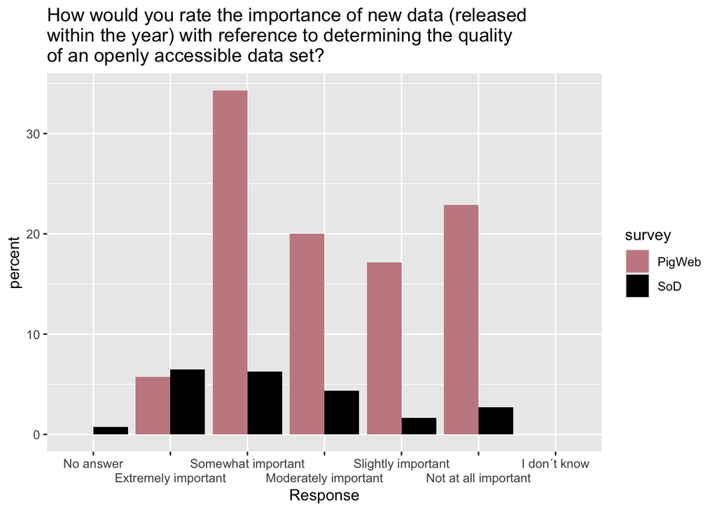

```r
#Creating data sets for column 125 and 128
pigw21Qleonie1 = as.data.frame(dplyr::select(pigw21, 125))
pigw21Pile = cbind(pigw21Pile, pigw21Qleonie1)

sod21Qleonie1 = as.data.frame(dplyr::select(sod21, 128))
sod21Pile = cbind(sod21Pile, sod21Qleonie1)



#Saving the Question text and changing the column name with the responses in the two data frames to Q45
Qleonie1 = "How would you rate the importance of new data (released within the year) with reference to determining the quality of an openly accessible data set? "
colnames(pigw21Qleonie1 ) = c('Qleonie1 ')
colnames(sod21Qleonie1 ) = c('Qleonie1 ')

Qleonie1_levels = c("Extremely important", "Somewhat important", "Moderately important","Slightly important","Not at all important","I don´t know") #The different levels/categories of the questions

Qleonie1_data = format_question_single_choice(sod21Qleonie1$Qleonie1, #Making the answers to Q45 in the two questionnaires comparable, merging them to one data frame
                                         pigw21Qleonie1$Qleonie1,
                                         Qleonie1_levels)

plot_single_choice(Qleonie1_data, #Plotting the responses
                   Qleonie1_levels,
                  Qleonie1,
                   "Response")
```

About.your.research.data…Are.you.aware.of.any.of.the.following.data.or.code.sharing.platforms….EOSC..European.Open.Science.Cloud.

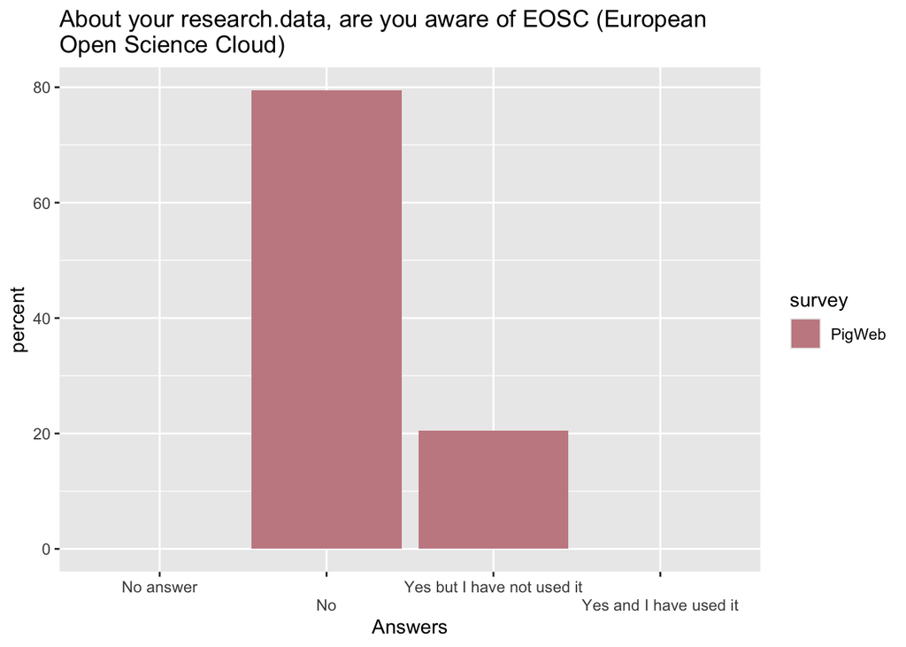

```r
#This is a single choice question without an "other" with responses only in the PigWeb survey.

pigw21Qleonie2 = as.data.frame(dplyr::select(pigw21, 89))


Qleonie2 = 'About your research.data, are you aware of EOSC (European Open Science Cloud)'
colnames(pigw21Qleonie2) = c('Qleonie2')

Qleonie2_levels = c("No", "Yes but I have not used it ", "Yes and I have used it")

#The function is given a 0 instead of the column expected form the SoD survey as there is no question in it.
Qleonie2_data = format_question_single_choice_pigweb(pigw21Qleonie2$Qleonie2,
                                       Qleonie2_levels)

plot_single_choice(Qleonie2_data,
                   Qleonie2_levels,
                   Qleonie2 ,
                   "Answers")
```